# Water Resources in Copenhagen during 20th century - 01

Adela Sobotkova

March-2021 updated2021-03-16

This script visualizes the spatial component of the data accompanying the Spring 2021 course on the City: Between Culture and Nature, taught by Mikkel Thelle and Mikkel Høghøj. The course surveys the gradual appearance of private and public bathing facilities, toilets and communal hygienic resources in the city of Copenhagen during the 20th century. By editing elements in this script, you can explore different aspects of past and present hygienic amenities in the capital of Denmark.

# Before we start: data wrangling

First load the packages necessary for spatial data visualisation and analysis.

```r
library(sf)
library(tidyverse)
library(googlesheets4)
library(leaflet)
```

## Spatial data

Next, load your spatial data - polygons representing the suburbs of Copenhagen.

```r
suburbs <- st_read("data/bydel.shp", options = "ENCODING=WINDOWS-1252")  # thank you, Malte, for the options argument which fixed the Danish chars
```

```
options:        ENCODING=WINDOWS-1252
```

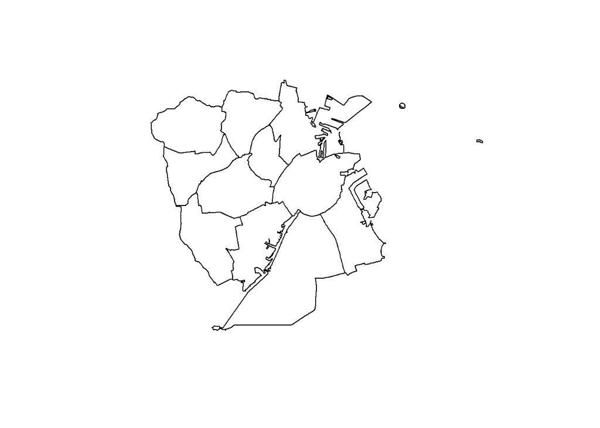

```r
plot(suburbs$geometry)
```

```r
tail(suburbs)
```

```
Simple feature collection with 6 features and 4 fields
geometry type:  MULTIPOLYGON
dimension:      XY
bbox:           xmin: 12.46344 ymin: 55.63174 xmax: 12.73425 ymax: 55.73271
geographic CRS: WGS 84
   id bydel_nr                      navn areal_m2
5   6        6                   Vanløse  6699011
6   5        5                     Valby  9234177
7   4        4 Vesterbro-Kongens Enghave  8472602
8   1        1                  Indre By 10488466
9   9        9                Amager Øst  9820410
10  2        2                  Østerbro  9858740
                         geometry
5  MULTIPOLYGON (((12.4982 55....
6  MULTIPOLYGON (((12.52434 55...
7  MULTIPOLYGON (((12.54553 55...
8  MULTIPOLYGON (((12.72897 55...
9  MULTIPOLYGON (((12.63082 55...
10 MULTIPOLYGON (((12.59777 55...
```

```r
# write_rds(suburbs, 'data/CPHsuburbs.rds')

suburbs$id
```

```
 [1]  3  7  8 10  6  5  4  1  9  2
```

## Attribute data

Next let’s bring in the attribute data. I read the data from a google sheet where my colleagues and I can edit it. You can load it from there if you have a `googlesheets4` package installed, or you can use the `read_csv()` function to read the `wc.csv` provided in the data folder

```r
# Uncomment the lines below to read data from GDrive wc <-
# read_sheet('https://docs.google.com/spreadsheets/d/1iFvycp6M6bF8GBkGjA2Yde2yCIhiy5_slAkGF-RUF7w/edit#gid=0',
# col_types = 'cnnnnnnnn') write_csv(wc, 'data/wc.csv')
wc <- read_csv("data/wc.csv")
wc
```

```
# A tibble: 100 x 9
   Suburb suburb_id flats wc_access  bath  year bath_communal_ct wc_communal_ct
   <chr>      <dbl> <dbl>     <dbl> <dbl> <dbl>            <dbl>          <dbl>
 1 Indre~         1 16280     11310  3800  1950               NA             NA
 2 Chris~         1  5490      3900   900  1950               NA             NA
 3 Voldk~         1 13460     12690  4560  1950               NA             NA
 4 Øster~         2 30820     28900 13750  1950               NA             NA
 5 Indre~         3 28700     24380  5910  1950               NA             NA
 6 Ydre ~         3 21710     20410  5800  1950               NA             NA
 7 Veste~         4 25850     23930  3730  1950               NA             NA
 8 Konge~         4  6270      6240  4240  1950               NA             NA
 9 Valby          5 14430     13970  8190  1950               NA             NA
10 Viger~         5  7700      7580  5050  1950               NA             NA
# ... with 90 more rows, and 1 more variable: hot_water <dbl>
```

## Spatial resolution adjustment - data aggregation

Data on access to hygienic facilities and other water resources in Copenhagen now looks good and tidy, but its *spatial resolution* is higher than the provided polygons (as in we have multiple rows that all fit within one suburb `id`). We therefore use the `group_by()` function to aggregate the data by id before we continue with any spatial operations. Given that the dataset is in fact a time-series, and each `kvarter` has a record for a given year or decade, we need to group first by the `year` and then only by `id`.

While aggregating the finer scale data into larger units, it is convenient to generate some statistics, such as percentages of flats that have bath and wc and hot water access within each suburb. We do this using the `summarize()` function below.

```r
wcdata <- wc %>% group_by(year, suburb_id) %>% summarize(flats = sum(flats), bath = sum(bath),
    pct_bath = bath/flats * 100, wc_access = sum(wc_access), pct_wc = wc_access/flats *
        100, warmH20 = sum(hot_water), pct_wH20 = warmH20/flats * 100, communal_wc = sum(wc_communal_ct),
    communal_bath = sum(bath_communal_ct))
wcdata
```

```
# A tibble: 50 x 11
# Groups:   year [5]
    year suburb_id flats  bath pct_bath wc_access pct_wc warmH20 pct_wH20
   <dbl>     <dbl> <dbl> <dbl>    <dbl>     <dbl>  <dbl>   <dbl>    <dbl>
 1  1950         1 35230  9260     26.3     27900   79.2    8530     24.2
 2  1950         2 30820 13750     44.6     28900   93.8   10750     34.9
 3  1950         3 50410 11710     23.2     44790   88.9    8810     17.5
 4  1950         4 32120  7970     24.8     30170   93.9    6110     19.0
 5  1950         5 22130 13240     59.8     21550   97.4   10830     48.9
 6  1950         6 10260  6780     66.1     10120   98.6    6270     61.1
 7  1950         7 27260 14790     54.3     26770   98.2   13280     48.7
 8  1950         8 19270 15000     77.8     18980   98.5   14690     76.2
 9  1950         9 23960 12470     52.0     22950   95.8   11210     46.8
10  1950        10 18000  9030     50.2     16200   90      7800     43.3
# ... with 40 more rows, and 2 more variables: communal_wc <dbl>,
#   communal_bath <dbl>
```

```r
# write_rds(wcdata, 'data/CPH_wcdata.rds')
```

## Join the aggregated attribute data with its spatial representations

Now we can join the data with the spatial polygons

```r
wc_spatial <- suburbs %>% merge(wcdata, by.x = "id", by.y = "suburb_id")
wc_spatial
```

```
Simple feature collection with 50 features and 14 fields
geometry type:  MULTIPOLYGON
dimension:      XY
bbox:           xmin: 12.45305 ymin: 55.61284 xmax: 12.73425 ymax: 55.73271
geographic CRS: WGS 84
First 10 features:
   id bydel_nr     navn areal_m2 year flats  bath pct_bath wc_access   pct_wc
1   1        1 Indre By 10488466 1981 26413 14035 53.13671     22546 85.35948
2   1        1 Indre By 10488466 1950 35230  9260 26.28442     27900 79.19387
3   1        1 Indre By 10488466 1965 32470 12780 39.35941     32450 99.93840
4   1        1 Indre By 10488466 1970 30440 11386 37.40473     22381 73.52497
5   1        1 Indre By 10488466 1955 33490  9740 29.08331     33430 99.82084
6   2        2 Østerbro  9858740 1950 30820 13750 44.61389     28900 93.77028
7   2        2 Østerbro  9858740 1955 30540 14060 46.03798     30510 99.90177
8   2        2 Østerbro  9858740 1965 32210 17340 53.83421     32190 99.93791
9   2        2 Østerbro  9858740 1970 32464 17728 54.60818     28139 86.67755
10  2        2 Østerbro  9858740 1981 32448 20255 62.42295     29343 90.43084
   warmH20 pct_wH20 communal_wc communal_bath                       geometry
1       NA       NA          NA            NA MULTIPOLYGON (((12.72897 55...
2     8530 24.21232          NA            NA MULTIPOLYGON (((12.72897 55...
3       NA       NA        9510          2280 MULTIPOLYGON (((12.72897 55...
4       NA       NA          NA            NA MULTIPOLYGON (((12.72897 55...
5     9130 27.26187          NA            NA MULTIPOLYGON (((12.72897 55...
6    10750 34.87995          NA            NA MULTIPOLYGON (((12.59777 55...
7    11660 38.17944          NA            NA MULTIPOLYGON (((12.59777 55...
8       NA       NA        4670           920 MULTIPOLYGON (((12.59777 55...
9       NA       NA          NA            NA MULTIPOLYGON (((12.59777 55...
10      NA       NA          NA            NA MULTIPOLYGON (((12.59777 55...
```

Now that we have a merged spatial dataset with attributes, let’s review what attributes are available for visualisation

```r
# Review the column names to see what new columns you have created
names(wc_spatial)
```

```
 [1] "id"            "bydel_nr"      "navn"          "areal_m2"
 [5] "year"          "flats"         "bath"          "pct_bath"
 [9] "wc_access"     "pct_wc"        "warmH20"       "pct_wH20"
[13] "communal_wc"   "communal_bath" "geometry"
```

There is the suburb polygon data, such as id, bydel_nr, navn and areal_m2, and there is also the attribute data such as year, flats, bath ,etc. This gives us lots of choices for display. Lets put the data in a map.

# Plot the data on the map

Let’s start by plotting one year alone, to learn how the map works.

## Flats and water resources in 1950

Run the whole chunk below, and once it renders, look at the map. Afterwards, try changing the definition of what is to be displayed on line 116. For example, replace `"flats"` for some other column, such as `"pct_bath"`, or `"wc_access"` to see how the map changes. To modify the legend, you can modify line 118 where we describe `style`. Replace `style = "jenks"` with `"pretty"`, or `"equal"`, or `"quantile"`. What happens to your classification?

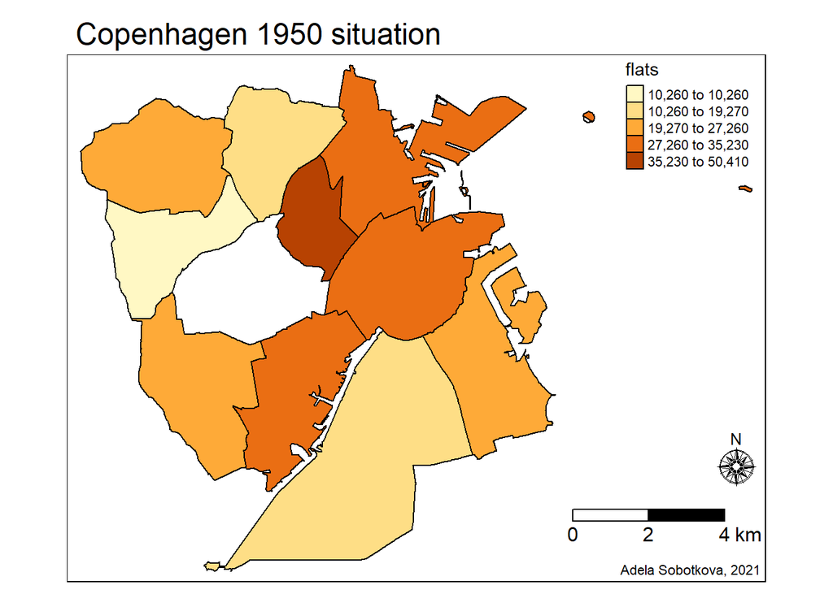

```r
wc1950 <- wc_spatial %>% filter(year == 1950)

library(tmap)
tmap_mode(mode = "plot")
tm_shape(wc1950) + tm_borders(col = "black", lwd = 1) + tm_polygons("flats", id = "navn",
    style = "jenks") + tm_legend(legend.position = c("RIGHT", "TOP")) + tm_compass(position = c("RIGHT",
    "BOTTOM"), type = "rose", size = 2) + tm_scale_bar(position = c("RIGHT", "BOTTOM"),
    breaks = c(0, 2, 4), text.size = 1) + tm_credits(position = c("RIGHT", "BOTTOM"),
    text = "Adela Sobotkova, 2021") + tm_layout(main.title = "Copenhagen 1950 situation",
    legend.outside = FALSE)
```

## Flats through time

Now, that you have mastered visualization of a single year, let’s plot all the years we have available!

```r
tmap_options(limits = c(facets.view = 5))  # we want to view 5 periods
tmap_mode(mode = "view")
tm_shape(wc_spatial) + tm_facets(by = "year", ncol = 5) + tm_polygons("flats", id = "navn",
    style = "jenks") + tm_layout(main.title = "Copenhagen Flats", legend.outside = TRUE)
```

[interactive chart not shown]